# ThreadScheduler

## R Code for ThreadScheduling Probability

There are Two Processcor cores each capable of running 2 threads. A stress test is required to be performed in the design on a FPGA platform. A selection of tests are picked at random from a pool of tests.

The expectation was that the tests would run without any hitch over a number of iterations or tries, the hypothesis being that the probability of occurance of 3 slave mode tests scheduled without a corresponding master is very slim.

In reality, it was otherwise

This R program plots the probability of the test Success abd Test Fail over given number of tries and proves that it does not take many tries to end up with a failure

```r
#This program attempts to get the plot of sucessful runs over number of tries
library(dplyr)
library(RSQLite)
library(tidyr)
library(ggplot2)
library(readr)
library(stringr)
library(scales)
library(mixtools)
```

## Details

Here is how the test is set up

- There are 4 tests A, B, C, and D
  - Further more, test A can run in Master or slave modes - M or S
- There are 2 cores with two threads each
- Each thread is named t<sub>0</sub>, t<sub>1</sub>, t<sub>2</sub> and t<sub>3</sub>
- 4 instances of each test is picked at random and scheduled
- 4 instances of each of the tests, A,B, C and D create a pool of 16 tests to choose from
- For all practical purposes, the total pool of tests can be thought of as
  - MSSS
  - BBBB
  - CCCC
  - DDDD
- There are 4 threads to schedule from this pool of tests
- Only if M is scheduled in t<sub>0</sub>, S can run sucessfully
  - e.g MSSS runs successfully -> q3
    - MSSX runs successfully
    - MSXS runs successfully ->q2
    - MXSS runs successfully
    - MSXX runs successfully
    - MXSX runs successfully ->q1
    - MXXS runs successfully
    - MXXX runs successfully ->q0
    - XXXX runs successfully ->qx # Probability
- Example
  - A in slave mode (S) can be picked picked with a probability of 4/16 into t<sub>1</sub>
  - A in slave mode (S) can be picked picked with a probability of 3/15 into t<sub>2</sub>
  - A in slave mode (S) can be picked picked with a probability of 2/14 into t<sub>3</sub>
  - A in Master mode (M) can be picked picked with a probability of 1/13 into t<sub>0</sub>
  - Let q<sub>3</sub> be the probability of a successful thread scheduling

#### Let us set up the Probability of the other cases enumerated above

```r
q3 <- (1/13) * (4/16) * (3/15) * (2/14)

q2 <- 3 * (2/13) * (4/16) * (3 /15)* (12/14)

q1 <- 3 * (3/13) * 3 * (4/16) * (12/15) * (11/14)

q0 <- (4/13) * (12/16) * (11/15) * (10/14)

qx <- (12/16) * (11/15) * (10/14) * (9/13)
```

#### total probability of a sucessful run in 1 try

```r
q <- q3 + q2 + q1 + q0 + qx
q
```

```
## [1] 0.7395604
```

#### probability of failure in 1st try

```r
 1-q
```

```
## [1] 0.2604396
```

#### Probability of failure in 2 trys

```r
q * ( 1-q)
```

```
## [1] 0.1926108
```

#### Probability of failure in 3 trys

```r
q*q *( 1-q)
```

```
## [1] 0.1424473
```

#### probability of failure in 4096th try

```r
q^4095 * ( 1-q)
```

```
## [1] 0
```

#### Probability of success in 4096 tries

```r
P <- q^4096
P
```

```
## [1] 0
```

#### Probability of failure in 4096 tries

```r
F <- 1-P
F
```

```
## [1] 1
```

#### Define a function

```r
# gives success probability in xth tries
sched_success <- function (x, q) { q^(x)}

# gives success probability in xth tries
sched_fail    <- function (x, q) { 1 -  (q^(x))}

# create a vector of
tries <- c(seq(1,20, by = 1))
```

#### print y pass

```r
y_pass <- sapply(tries, sched_success,q)
y_pass
```

```
##  [1] 0.739560440 0.546949644 0.404502319 0.299153913 0.221242399
##  [6] 0.163622126 0.121008451 0.089493064 0.066185529 0.048948199
## [11] 0.036200152 0.026772200 0.019799660 0.014643045 0.010829417
## [16] 0.008009008 0.005923146 0.004380524 0.003239662 0.002395926
```

#### print y fail

```r
y_fail <- sapply(tries, sched_fail,q)
y_fail
```

```
##  [1] 0.2604396 0.4530504 0.5954977 0.7008461 0.7787576 0.8363779 0.8789915
##  [8] 0.9105069 0.9338145 0.9510518 0.9637998 0.9732278 0.9802003 0.9853570
## [15] 0.9891706 0.9919910 0.9940769 0.9956195 0.9967603 0.9976041
```

# Plot

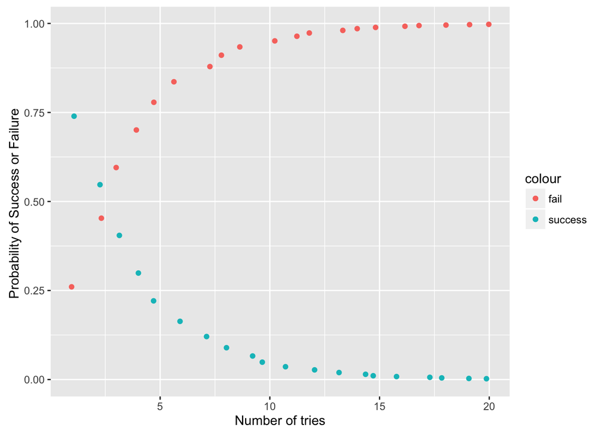